# United States Trends in Turbulent Weather

Erica Laidler

2023-08-31

**Introduction**

Erratic weather may be the new normal for the children who grow up in the world today. In the wake of a worsening climate crisis, likely the most alarming and crucial issue of our generation, we can expect to experience different conditions than we are used to. Climate change has already contributed to an array of cascading effects, including more frequent and extreme storms, heat waves, dry spells, higher sea levels, and warming oceans (WWF). As time goes on, unless we collectively take serious systemic measures to slow the effects, it will continue to wreak havoc on animal habitats and our communities. In this project, I focus on extreme weather patterns, specifically erratic precipitation in the United States.

Climate change tends to produce extremes in the temperature, creating longer, more intense heat spells and more frigid winters. However, changes in precipitation are also common, including blizzards, destructive hurricanes, and droughts.

My research goal is to detect notable extremes and pattern changes in US precipitation over the the last century. I determine which states in the US have experienced the greatest extremes in precipitation; notably, the highest precipitation months, lowest precipitation months, and most dramatic seasonal differences. My second research goal is to determine if the weather patterns for any of these erratic states have changed significantly in the last century.

**Findings**

In 2021, Alaska had the highest monthly precipitation measurement, at 28.78 inches. Ten states, including Arizona, California, Colorado, and Kansas, experienced the lowest precipitation, at 0 inches. Overall, in 2021, Alaska, Oregon, Washington, and Louisiana faced the most dramatic seasonal changes in precipitation, or the greatest difference between their highest and lowest recorded monthly precipitation measurements. The quantitative evidence suggests that Louisiana may have faced a particularly dramatic increase in extreme weather patterns during the years since 1895. More research is necessary to determine if this is a statistically significant trend.

**Data**

This research uses a dataset from the National Centers for Environmental Information, which provides detailed climate data in the US. It can be found at: https://www.ncei.noaa.gov/data/climdiv/ (data set ‘pcpncy’). This particular data set contains records of the total precipitation which fell in each state region over the course of every month from 1895 to 2022. It is updated monthly, and published online for public use.

**Tidying the Data**

Structuring the data set into a more useful, easily comprehensible form required significant tidying. In the original data set, the row names are coded. Certain digits of the row names represent the state, metric (temperature or precipitation), and year which are associated with that particular row.

The data set is not very immediately interpretable. According to the code book, the first 1-2 digits of the row names represent a state ID associated with a particular state. The next three digits represent the state division. The next digit represents the metric (“temperature” or “precipitation”), and the last four represent the year. In turn, each of the 12 columns represents a month, and contain the relevant weather measurements for that row. The elements in the data frame are all of type double, because they refers to a precipitation measurement (in inches).

Ultimately, I wanted the final form of the data set to contain 16 columns. The first 12 would remain the 12 months of the year, but the next columns would be state, division, metric, and year. This format would make the information about each row much more clear. Further analysis of the data set will not require extraction of subsets of the digits of the row names. For instance, to analyze Maryland precipitation in April, one can refer to the categorical column ‘state’ and subset based on the Maryland state ID, as opposed to referring to the cumbersome coded row names.

I made some basic tidying adjustments, and then added four new recoded columns to the data set. Now the data frame is tidied. The row names are now simply ID numbers from 1 to 400,636. I added columns for state, division, metric, year, and metric name. The first 12 columns of each row contains the precipitation or temperature value from January to December for a specific state, division, and year. The metric column tells us the coded number for the metric being reported in that row. However, it is coded as a number so I included an additional column, metric_name, which tells us whether the metric represented in that row is precipitation, average temperature, maximum temperature, or minimum temperature. I choose to keep the columns state and division coded, which means that it will be useful to have the legend available during further analysis of the data set.

I made some final edits upon further exploration of the data. First, I observed that all the measurements in this particular data set were precipitation measurements, by finding that every categorical value in column 15 (‘metric’) was ‘precipitation’. For this reason, I eliminated the metric and metric_name columns, as they provided no extra information.

I also removed the rows for 2022. This is because upon exploration of the dataset, I noticed that these rows contained the value -9.99 for a lot of their entries. 2022 was the only year for which this happened. There is no explicit mention of this on the website where the data set originated, but my guess is that the data was collected mid-way through 2022, meaning that they left a lot of entries with negative default values.

**Understanding the Data**

The first research goal was to determine which state had the highest precipitation measurement, lowest measurement, and greatest range in 2021, such that the difference between the measurement for its highest-precipitation month and its lowest-precipitation measurement in 2021 was the greatest out of all the states.

To find this value, I took three main steps. First, I found the highest precipitation measurement in all of 2021 for each state. Then, I found the lowest measurement for each state. Finally, I was able to find the range of precipitation by calculating the difference between the highest and lowest precipitation measurements for each state. The state with the largest of these values had the largest range.

In this paper, a single precipitation measurement refers to the cumulative precipitation in a particular division over the course of a month. Thus, the highest measurement of the month for a state is the highest measurement out of all its divisions for that month.

For the first step, I iterated over the twelve months of data. The list ‘highest’ represents the highest precipitation measurements of the year. More specifically, it contains 12 lists, which represent the 12 months of 2021. Each list contains the highest precipitation measurements for all 49 states for the associated month. In turn, ‘max_val’ is a 49-element list which contains each of the states’ highest recorded precipitation measurements for the entire year.

For the second step, I found the lowest precipitation measurements. The list ‘lowest’ represents the lowest precipitation measurements of 2021, specifically the lowest values for each state in every month. The min_val vector contains the lowest recorded precipitation measurement for each of the 49 states in the year 2021.

A few observations are evident. According to the data set, Alaska (state #49) has the highest precipitation measurement out of all the states in the US in 2021, at 28.78 inches. This is followed by Washington (27.09 in), Oregon (20.89), and Louisiana (20.16).

Meanwhile, there are 10 states with the lowest precipitation measurements, at 0 inches. It is possible for there to be no rain at all during some months. The 10 states are Arizona, California, Colorado, Kansas, Nevada, New Mexico, Oklahoma, Oregon, Texas, and Washington.

The third step was to find the state with the highest range in monthly precipitation, suggesting that their rainy season is the most drastically different from their dry season.

All three of the states with the largest range in precipitation, especially Alaska and Oregon, have very high annual rates of snowfall. This could definitely be contributing to the annual precipitation measurements. Thus, to isolate rainfall as a variable of interest, I choose to focus on Louisiana, which has a warm climate and tends to receive less than an inch of snow every year (Snow Climatology).

As mentioned, Louisiana has the fourth largest range in precipitation. As it turns out, Louisiana has a significant rainy season. In fact, WorldAtlas.com explains that Louisiana tends to be the second rainiest state in the entire United States. Hawaii is the first rainiest, but upon checking the code book Hawaii is the only state which is not represented in the data set. Overall, the findings of this 2021 study are in alignment with existing research.

**Visualizations**

Based on the fact that Louisiana has the fourth highest range in precipitation over the course of 2021, I wanted to see if there are particular months during which the rain tends to be much more extreme. I plot the data for June and November in Louisiana, from 2000 to 2021, below.

Plot A. Comparison of Rainfall in Louisiana in June and November from 2000 to 2021

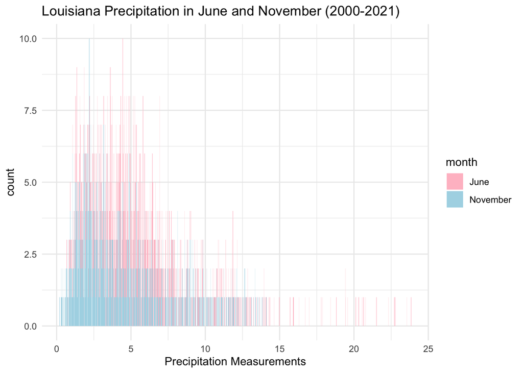

It does appear that overall there tended to be more Louisiana precipitation (including more extremely high precipitation measurements) in June than in November.

Plot A is the product of two simple histograms layered over one another. One histogram (in light blue) represents November precipitation measurements in Louisiana from 2000 to 2021. The other histogram (in pink) represents June precipitation measurements in Louisiana from 2000 to 2021.

The other research question addresses whether Louisiana has changed its precipitation patterns in the years since 2000.

Plot B. Rainfall in Louisiana in June from 2000 to 2021

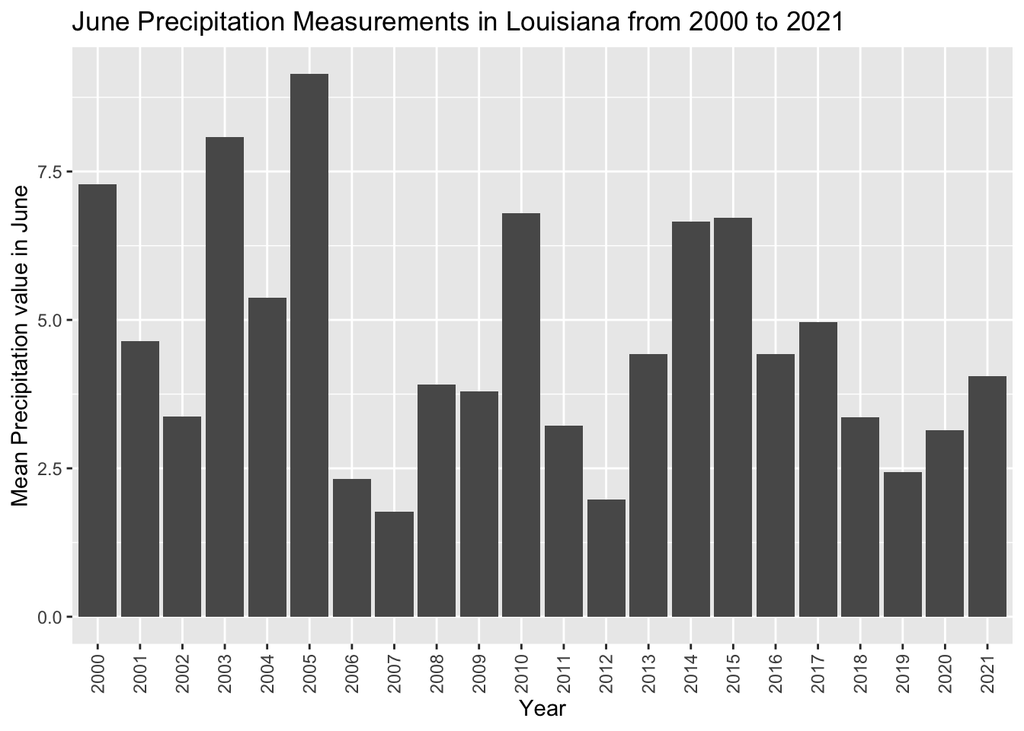

In this plot, I incorporate two variables: precipitation in Louisiana, and time. More specifically, in the plot above, the x-axis represents the year, while the y-axis represents June precipitation measurements collected in that year. The question I was curious to answer was whether or not there were significant changes in the June precipitation trends from 2000 to 2021. Based on a general analysis of the plot, it is possible that Louisiana has had less rain in recent years. However, more analysis would have to be conducted to verify if this was a significant difference.

[figure not shown]

**Reflection**

Weather is not an easy subject of analysis. Though it is relatively quantifiable, especially precipitation, it is highly variable and subject to many factors, many of which we are unlikely to assess, like the temperature of the upper layers of the atmosphere. However, data analytics makes it possible to synthesize very large amounts of information and come to useful conclusions.

One of the most challenging parts of this project was the data tidying process. At the beginning, it is very difficult to know what research questions will prove to be most relevant. As a result, deciding what structure the data frame should take is not always obvious. This data set in particular was far more complex and difficult to interpret than any other one I have had experience with. In most classes, for instance, the data set is already tidy, with columns that represent variables and rows which represent observations. In this data set, not only was this not the case, but it was also not very clear what should be considered variables. For instance, it would have been possible to consider ‘month’ as a single categorical variable, with 12 levels, or to consider the precipitation value for each month as its own observation.

Even after recoding the variables based on the ID’s in the row names, I ran into challenges. While analyzing the data, for instance, I noticed that certain outputs did not make sense contextually. Upon further investigation, I found that this was because the data associated with 2022 contained negative values, and had to be eliminated. Overall, this and other difficulties taught me that it is very important to thoroughly familiarize yourself with the data. It is helpful to plot variables as part of a general exploratory analysis, to get a general sense of their distributions as well as any outliers.

Debugging is always crucial. It is important never to assume, without checking, that the code is working properly, even if it is producing an output which looks reasonable. It is important to debug the code carefully, verifying at multiple points within each code chunk to make sure that it is performing the task that you want it to, as well as ascertaining that none of the outputs look unusual. Especially in datasets such as this one, in which we are dealing with divisions within states, and months within years, it is important to verify that the functions are performing the intended task.

If I were to continue with my work, the natural trajectory would be to continue to uncover possible trends in erratic weather in certain states in the US. My project performed preliminary analysis on the trends over time in Louisiana, which I identified to be one of the states with the most dramatic highs and lows in precipitation in the country. If I were to continue with this project, I would isolate other states with large ranges in precipitation and perform more extensive analysis on the trends since 1895. It would be very informative to incorporate statistical analysis and comparisons between the amount of precipitation in past years and now. Further research, and the implementation of statistical modeling and regression techniques like support vector machines, could also yield predictions of future climate and precipitation changes.

**Conclusion**

Further research should focus on states with turbulent weather patterns, to uncover the presence of possible changes which may be associated with climate change and predictions for future evolution.

**Bibliography**

Data set: “NOAA Monthly U.S. Climate Divisional Precipitation Database.” National Centers for Environmental Information., 31 Mar. 2022, https://www.ncei.noaa.gov/data/climdiv/.

“Climate and Average Weather Year Round in Alabama.” Weatherspark.com, https://weatherspark.com/y/20416/Average-Weather-in-Alabama-New-York-United-States-Year-Round#:~:text=The%20chance%20of%20wet%20days,least%200.04%20inches%20of%20precipitation.

Nag, Oishimaya Sen. “The 10 Wettest States in the United States of America.” WorldAtlas, WorldAtlas, 24 Apr. 2019, https://www.worldatlas.com/articles/the-10-wettest-states-in-the-united-states-of-america.html.

US Department of Commerce, NOAA. “NWS Lix - Snow Climatology.” National Weather Service, NOAA’s National Weather Service, 17 Nov. 2021, https://www.weather.gov/lix/snowcli.

Wickham, H., & Grolemund, G. (2016). R for data science: Visualize, model, transform, tidy, and import data. OReilly Media.